# 上級マクロ経済学II

第9回 景気循環とその抽出

Author

荻巣嘉高

# 1 景気変動へのイントロダクション

## トレンドとサイクル

経済変数の時間変動には

- トレンド
- サイクル
- 季節変動
- ショック

が存在すると考える．

- 経済成長理論はトレンドについて考慮してきていた．
- 今後はサイクルについての議論を行なっていく．

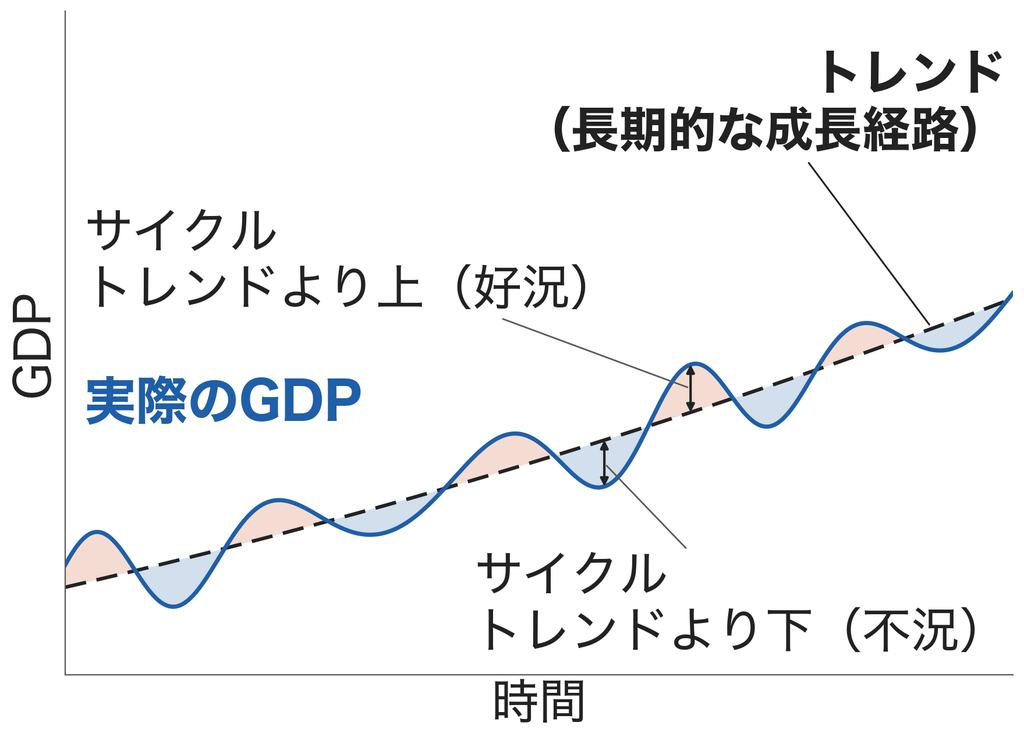

## 分解の基本形

$$\begin{aligned}
y_t &= (トレンド)_t + (サイクル)_t + (季節変動)_t + (ショック)_t \\
\Downarrow &~季節変動を除去 \\
\tilde{y}_t &= (トレンド)_t + (サイクル)_t + (ショック)_t \\
\Downarrow &~トレンドを除去 \\
\hat{y}_t &= (サイクル)_t + (ショック)_t \\
\end{aligned}$$

- トレンドは非定常的な成分である一方，サイクルは定常的な成分．
- ショックがサイクルを増幅させたり，減衰させたりする．
- 場合によっては季節変動は後から除去する場合も考えられる．

# 2 季節性とその除去

## 季節変動

- **季節性**：年間の消費スケジュール，投資スケジュール等できまったような変動が引き起こされる．
- 基本的には季節変動を除いた，季節調整済みデータを使う．
  - 季節性自体に関心がある場合は別．

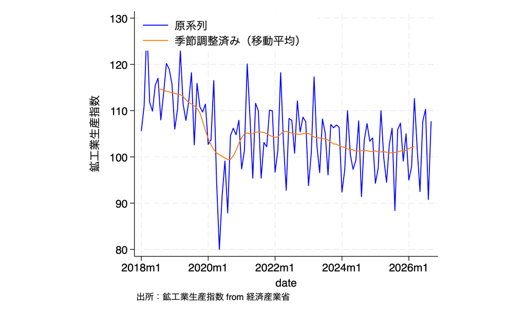

## 季節調整

最も単純な季節調整方法は移動平均法（Moving Average: MA）． 月次データの場合，以下の通りで調整．

- 中心化移動平均
  $$\hat{y}_t = \frac{y_{t-6}}{24} + \frac{y_{t-5}+y_{t-4}+\cdots + y_{t+4} + y_{t+5}}{12} + \frac{y_{t+6}}{24}$$
- 後方移動平均

$$\hat{y}_t = \frac{y_{t-11}+y_{t-10}+\cdots + y_{t-1} + y_{t}}{12}$$

先の図からも，季節変動を除いても，変動は存在することがわかる．

- トレンド+サイクル（+ショック）へ

# 3 トレンド

## 確定トレンド

$y_t$が毎期$a>0$ずつ成長するとしよう． このとき，次の関係が満たされている．
$$y_t - y_{t-1} = a$$

$y_0$が与えられれば，
$$y_t = y_0 + ta$$
これは時間$t$についての線形関数になっている．

- $ta$を確定トレンドと呼ぶ．

## 確率トレンド

$y_t$の成長$a>0$に，毎期独立なショック$u_t$が当たるケースを考えよう．
$$y_t - y_{t-1} = a + u_t$$

このとき，$y_0$を与えれば，

$$y_t = y_0 + ta + \sum_{s=1}^t u_s$$

$y_0 + \sum_{s=1}^t u_s$は一次関数の切片に当たる．

- 切片は$\sum_{s=1}^t u_s$によって確率的に変化しうることから，$\sum_{s=1}^t u_s$を確率トレンドと呼ぶ．
  - 確率的に水準（トレンド）をシフトさせうる．

## トレンド成分あれこれ

- 現実の経済データのトレンドは線形とは限らない．
  - 確定トレンドであれば線形だが，観測データには確率トレンドも含まれうる．
- トレンドを削除するだけなら，差分をとれば良い．
  - トレンドを抽出したいのであれば，フィルタリング（後述）などが必要．
  - 詳しい話は時系列解析を．

# 4 サイクル

## 循環とショック

季節性やトレンドで説明されない変動はサイクルと言われる．

- 変数のトレンドからの乖離は，時間を通じてトレンドへ戻っていく．
  - トレンド定常性
  - サイクルだけを取り出してみてみると，0付近でうろうろしていていずれ0に（定常性）．
- サイクルの要因は種々ある．
  - ショック
  - 過去のサイクルの影響
  - まとまった投資計画

## 景気の山と谷

- サイクルには山と谷が存在する．
- 日本の景気においては内閣府の[景気基準日付](https://www.esri.cao.go.jp/jp/stat/di/hiduke.html)にて設定されている．

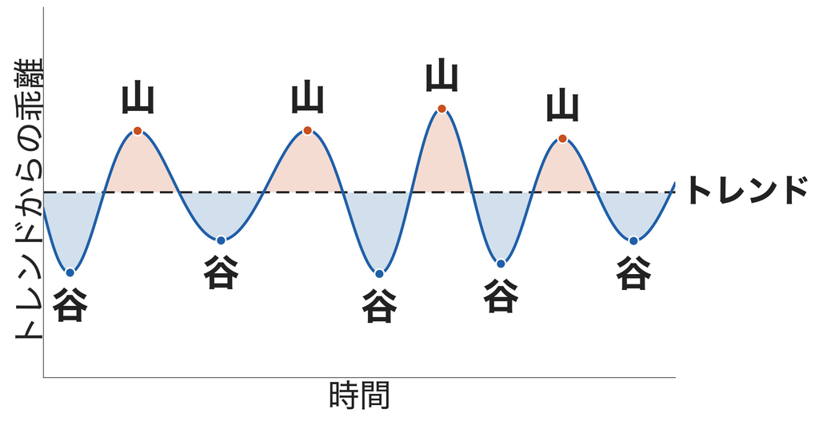

## 観測される山と谷

景気動向を把握するための代表的な指数

- 景気動向指数（右図）
- 景気ウォッチャー調査
- 日銀短観

CI・DIや調査対象の違いなどもあるので，適宜使い分ける．

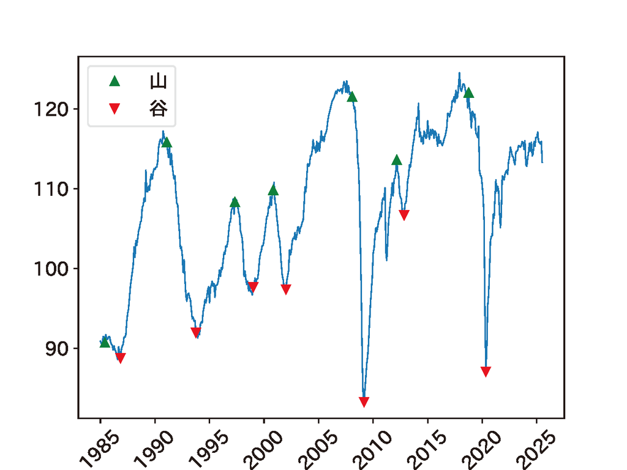

## なぜサイクルに注目するか

オイラー方程式
$$\frac{\partial u}{\partial c_1} = \left(\frac{1+r}{1+\rho}\right) \frac{\partial u}{\partial c_2}$$
をもとに，消費は平準化される．

- 極端な消費計画$(c_1, c_2) = (1,0)$などは選ばれない．
  - 消費者は，消費計画の変動を嫌う．
- 景気変動は，消費者の厚生を損ないうる．
  - そのあたりはモデルでの議論を後でするかも．

# 5 トレンド・サイクル分解

## トレンド・サイクル分解

現実のデータからフィルタリングを行なって，トレンドとサイクルを分解する．

- 色々な方法が提案されている．
  - ここで紹介するのは2つ（あとで）．
    - HPフィルター（Hodrick-Prescott filter）
    - Hamiltonフィルター（Hフィルター）
  - 他にもBN分解（Beveridge-Nelson decomposition）などもある．
    - 時系列解析の知識がいるので，今回はスキップ．
    - 関心のある人はエンダース（2019）などを参照．

## フィルタリングのベースライン

変数$y_t$をフィルタリングするとき，次のような構成になっていると想定する．
$$y_t = \tau_t + \psi_t + u_t$$

- $\tau_t$：トレンド成分
- $\psi_t$：サイクル成分
- $u_t$：ショック

ここからトレンド成分とそれ以外（サイクル成分+ショック）を抽出する．

## HPフィルター

変数の系列$\bm y=(y_t)_{t=1}^{T}$に対して，未知の$\bm \tau=(\tau_t)_{t=1}^{T}$について以下の目的関数を設定する．
$$O(\bm \tau;\lambda, \bm y) = \frac{1}{T} \sum_{t=1}^{T} \underbrace{(y_t - \tau_t)^2}_{\textrm{トレンドからの乖離}} + \frac{\lambda}{T} \sum_{t=2}^{T-1} \underbrace{[\Delta \tau_t - \Delta \tau_{t-1}]^2}_{\textrm{トレンドのスムーズさ}}$$

- $\Delta \tau_t = \tau_{t+1} - \tau_{t}$．
  - $\Delta \tau_t - \Delta \tau_{t-1} = \tau_{t+1} - 2\tau_t + \tau_{t-1}$を直接入れるのも数学的には同じ．
- $\lambda$はsmoothing parameterと呼ばれる．
  - 分析者が決める（後述）．
- $O$を最小化するような系列$\bm \tau$を決めて，トレンドを決定→サイクルも決定．

## トレンドのスムーズさと$\lambda$

- $\Delta \tau_t = \Delta \tau_{t-1}$なら，前期の成長と今期の成長が等しいので，線形トレンド．
  - $\lambda$が大きくなればなるほど，線形トレンドに近くなる．
  - $\lambda$が小さくなればトレンドからの乖離が大きくなることを嫌うので，ぐねぐね曲がったトレンドを許すようになる．

## $\lambda$のチョイス

| 頻度 | 月次 | 四半期 | 年次 |  |
| --- | --- | --- | --- | --- |
| $\lambda$ (recommended) | 129600 | 1600 | 6.25 | Ravn and Uhlig (2002) |
| $\lambda$ (conventionally) | 14400 | 1600 | 100 |  |

- Ravn and Uhlig (2002)では，周波数特性を等しく保つために，4乗ベースでの調整を提案．
- 四半期1600はHodrick and Prescott (1997)から．
  - ただし，統計的に強い根拠があるとは言えない．
  - 恣意的という指摘もある．

## Hamiltonフィルター

系列$\bm y$に対して，以下の設定で回帰をする．
$$y_t = \alpha + \sum_{i=s}^{e} \beta_i y_{t-i} + u_t$$

- 2年前から遡って1年分（四半期なら4期分）のデータで回帰する．
  - 分析者が2年前に合わせて$s$を決め，1年分となるように$e$を決める．

回帰後の推計値から，トレンドとサイクルを決める．

- トレンド：$\hat \alpha + \sum_{i=8}^{11} \hat \beta_i y_{t-i}$
- サイクル（＋ショック）：$\hat{u}_t$

## Hamiltonフィルターのアイデア

- 今発生した景気循環の変動要因は2年もあれば減衰しているはず，というアイデア．
  - 2年前のデータで予測可能な現在の値は，サイクルの成分を含んでいないはず．
    - 予測値をトレンドとしている．
  - 説明できない部分は今期に残っている循環的成分．
    - 残差をサイクルとしている．
- “2年”が恣意的という指摘もある．

## トレンド比較

- 四半期GDP（実質）を使ったフィルタリング
- HPフィルターの方がかなり滑らか．
  - ウエイトの恣意性が効くという実例．
    - とは言え，慣例的なものが守られていれば比較の上では問題ないが…

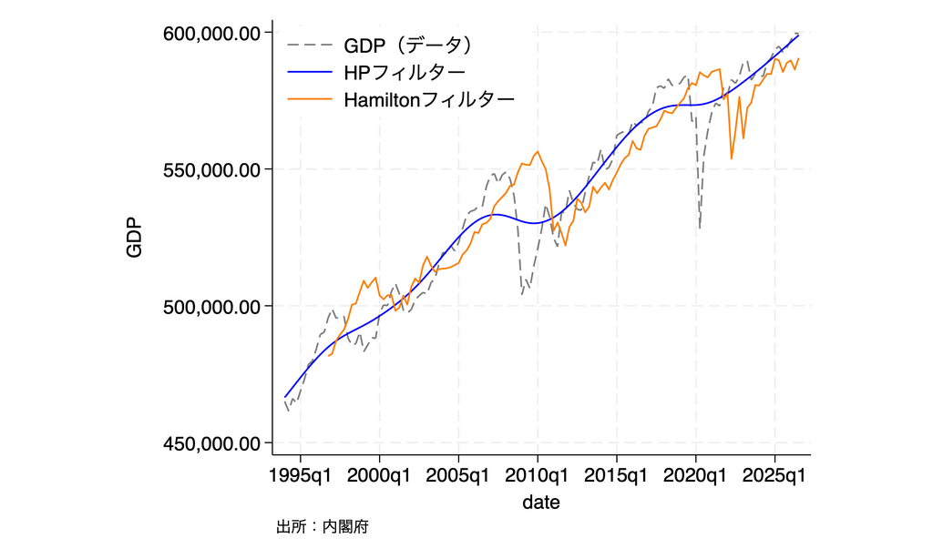

## サイクル比較

- そこまで傾向は変わらない．
- HPフィルターは大きなショックに推計が引っ張られがち．
- Hamiltonフィルターは過去の値のみからトレンドを予測するので，ショック時点のトレンドは影響を受けない．
  - ただし，大きなショックがその後のトレンド・サイクルを引っ張りやすい．
    - 跳ね返りがでかくなる．

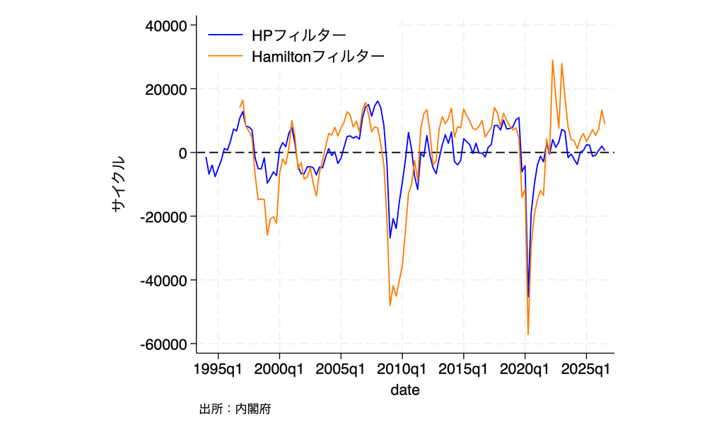

## 参考文献

- Hamilton, J. D. (2018) “Why you should never use the Hodrick-Prescott filter,” *Review of Economics and Statistics*, 100.
- Hodrick, R. J. and E. C. Prescott (1997) “Postwar US business cycles: an empirical investigation,” *Journal of Money, Credit, and Banking*, 29.
- Ravn, M. O. and H. Uhlig (2002) “On adjusting the Hodrick-Prescott filter for the frequency of observations,” *Review of Economics and Statistics*, 84.
- ウォルター・エンダース（2019）「実証のための計量時系列分析」有斐閣（新谷元嗣；藪友良訳）